# Metode Pemulusan_Rahma Annisa_M0401241092

Rahma Annisa

2026-08-30

# Data

# Struktur Data

Tanggal: menunjukkan tanggal pencatatan data(Format: DD/MM/YYYY) Periode: Indeks waktu berurutan dari 400-599 Harga: nilai harga penutupan bitcoin hari ini

# Library

Tahap ini memanggil packages R yang dibutuhkan dalam analisis pemulusan deret waktu. Packages “forecast” dan “TTR” digunakan untuk permodelan peramalan Deret Waktu dan pembuatan fungsi pemulusan. Packages “graphics” digunakan untuk visualisasi grafik. Packages “rio”untuk mengimpor file data dari excel

```r
library(forecast)
```

```r
library(graphics)
library(TTR)
library(rio)
```

#Iimpor data proses impor data dari file lokal ke R data pergerakan harian harga Bitcoin periode 400-600 menggunakan fungsi import () dari package rio

```r
data1 <- import("E:/Data Bitcoin 401-600_M0401241092.csv")
head(data1)
```

```
##           V1  V2            V3
## 1 06/01/2025 400 1.020.780.859
## 2 07/01/2025 401 9.692.270.313
## 3 08/01/2025 402 9.504.352.344
## 4 09/01/2025 403 9.248.403.906
## 5 10/01/2025 404 9.470.145.313
## 6 11/01/2025 405 9.456.659.375
```

```r
str(data1)
```

```
## 'data.frame':    200 obs. of  3 variables:
##  $ V1: chr  "06/01/2025" "07/01/2025" "08/01/2025" "09/01/2025" ...
##  $ V2: int  400 401 402 403 404 405 406 407 408 409 ...
##  $ V3: chr  "1.020.780.859" "9.692.270.313" "9.504.352.344" "9.248.403.906" ...
```

# Pembersihan data

Pada tahap ini nama kolom yang awalnya berupa variabel numerik (V1, v2, ddan V3) diubah menjadi (Tanggal, Periode, dan Harga)

```r
colnames(data1) <- c("Tanggal", "Periode", "Harga")

clean_price <- function(val) {
  val_str <- trimws(as.character(val))
  parts <- unlist(strsplit(val_str, "\\."))

  if (length(parts) == 4) {
    num <- as.numeric(paste(parts, collapse = ""))
    if (num > 2e9) num <- num / 10
    return(num)
  } else if (length(parts) == 3) {
    num <- as.numeric(paste(parts, collapse = ""))
    if (num < 5e8) num <- num * 10
    return(num)
  } else if (grepl("^[0-9]+\\.[0-9]+$", val_str) || grepl("^[0-9]+$", val_str)) {
    num <- as.numeric(val_str)
    if (num < 200000) num <- num * 10000
    return(num)
  } else {
    return(as.numeric(gsub("\\.", "", val_str)))
  }
}

data1$Harga_Clean <- sapply(data1$Harga, clean_price)
data_ts <- ts(data1$Harga_Clean)

head(data1)
```

```
##      Tanggal Periode         Harga Harga_Clean
## 1 06/01/2025     400 1.020.780.859  1020780859
## 2 07/01/2025     401 9.692.270.313   969227031
## 3 08/01/2025     402 9.504.352.344   950435234
## 4 09/01/2025     403 9.248.403.906   924840391
## 5 10/01/2025     404 9.470.145.313   947014531
## 6 11/01/2025     405 9.456.659.375   945665938
```

```r
summary(data_ts)
```

```
##      Min.   1st Qu.    Median      Mean   3rd Qu.      Max.
## 7.627e+08 8.749e+08 9.788e+08 9.826e+08 1.057e+09 1.200e+09
```

# Eksplorasi Data

Eksplorasi dilakukan untuk memvisualisasi data deret waktu ke dalam bentuk line chart

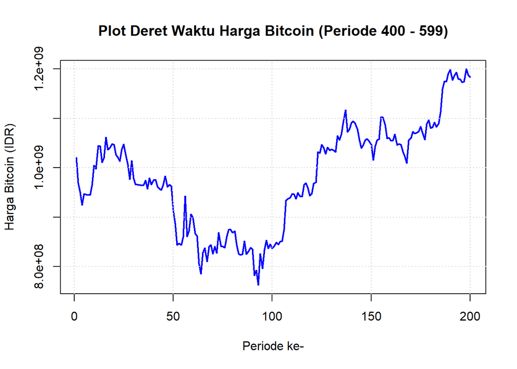

```r
plot(data_ts, type = "l", col = "blue", lwd = 2,
     main = "Plot Deret Waktu Harga Bitcoin (Periode 400 - 599)",
     xlab = "Periode ke-", ylab = "Harga Bitcoin (IDR)")
grid()
```

# Pembagian data (Train dan Test)

```r
n <- length(data_ts)
n_train <- round(0.8 * n)

train_data <- data_ts[1:n_train]
test_data <- data_ts[(n_train + 1):n]

cat("Jumlah data latih:", length(train_data), "\n")
```

```
## Jumlah data latih: 160
```

```r
cat("Jumlah data uji:", length(test_data), "\n")
```

```
## Jumlah data uji: 40
```

# Tahap pelatihan dan pengujian Model Single Moving Average (SMA)

Metode pemulusan pertama yang digunakan adalah SMA dengan orde k = 3. Fungsi SMA berasal dari package TTR digunakan untuk menghitung nilai pemulusan, kemudian hasilnya digeser saru periode ke depan untuk mendapatkan nilai peramalan.

```r
library(TTR)
k <- 3
#Menghitung nilai SMA pada data latih
sma_train <- SMA(train_data, n = k)

#Peramalan untuk data uji
ramalan_sma <- rep(tail(sma_train[!is.na(sma_train)], 1), length(test_data))

bandingan_sma <- data.frame(
  Data_Uji = test_data,
  Hasil_Ramalan = ramalan_sma
)
print(bandingan_sma)
```

```
##      Data_Uji Hasil_Ramalan
## 1  1055520234    1058308099
## 2  1067967578    1058308099
## 3  1046011172    1058308099
## 4  1048833281    1058308099
## 5  1046842891    1058308099
## 6  1033096016    1058308099
## 7  1022574063    1058308099
## 8  1009871406    1058308099
## 9  1055777734    1058308099
## 10 1060456328    1058308099
## 11 1073612578    1058308099
## 12 1069600000    1058308099
## 13 1070884297    1058308099
## 14 1073277031    1058308099
```

[output cut: 26 more lines]

```r
#Selisih error antaradata uji aktual dengan hasil peramalan
error_sma <- test_data - ramalan_sma

#Menghitung nilai akurasi MAD, MSE, dan MAPE
mad_sma <- mean(abs(error_sma), na.rm = TRUE)
mse_sma <- mean(error_sma^2, na.rm = TRUE)
mape_sma <- mean(abs(error_sma / test_data), na.rm = TRUE) * 100

cat("MAD SMA:", mad_sma, "\n")
```

```
## MAD SMA: 59341540
```

```r
cat("MSE SMA:", mse_sma, "\n")
```

```
## MSE SMA: 6.197327e+15
```

```r
cat("MAPE SMA:", mape_sma, "% \n")
```

```
## MAPE SMA: 5.130869 %
```

Nilai MAPE SMA sebesar 5,13% menunjukkan bahwa model SMA memiliki tingkat akurasi yang sangat baik dalam mengidentifikasi tren data karena di bawah standar umum evaluasi peramalan yaitu 10%

# Tahap pelatihan dan pengujian Double Moving Average(DMA)

Metode pemulusan keduayaitu DMA untuk meramalkan deret waktu yang memiliki pola tren linear, menerapkan moving average sebanyak dua kali secara berurutan kemudian menghitung nilai konstanta dan kemiringan untuk menghasilkan nilai peramalan

```r
#Perhitungan pemulusan menggunakan data latih
sma1 <- SMA(train_data, n = 3)
sma2 <- SMA(sma1, n = 3)
At <- 2 * sma1 - sma2
Bt <- (2 / (3 - 1)) * (sma1 - sma2)

#Peramalan untuk periode data uji
h_uji <- length(test_data)
ramalan_dma <- numeric(h_uji)
for (i in 1:h_uji) {
  ramalan_dma[i] <- tail(At, 1) + tail(Bt, 1) * i
}

#Perbandingan data uji dan hasil ramalan
bandingan_dma <- data.frame(
  Data_Uji = test_data,
  Hasil_Ramalan = ramalan_dma
)
print(bandingan_dma)
```

```
##      Data_Uji Hasil_Ramalan
## 1  1055520234    1034764315
## 2  1067967578    1022992423
## 3  1046011172    1011220530
## 4  1048833281     999448638
## 5  1046842891     987676746
## 6  1033096016     975904854
## 7  1022574063     964132962
## 8  1009871406     952361069
## 9  1055777734     940589177
## 10 1060456328     928817285
## 11 1073612578     917045393
## 12 1069600000     905273500
## 13 1070884297     893501608
## 14 1073277031     881729716
```

[output cut: 26 more lines]

```r
#Evaluasi akurasi (MAD, MSE, MAPE)
error_dma <- test_data - ramalan_dma
mad_dma <- mean(abs(error_dma), na.rm = TRUE)
mse_dma <- mean(error_dma^2, na.rm = TRUE)
mape_dma <- mean(abs(error_dma / test_data), na.rm = TRUE) * 100

cat("MAD DMA:", mad_dma, "\n")
```

```
## MAD DMA: 304974058
```

```r
cat("MSE DMA:", mse_dma, "\n")
```

```
## MSE DMA: 1.297379e+17
```

```r
cat("MAPE DMA:", mape_dma, "% \n")
```

```
## MAPE DMA: 26.67125 %
```

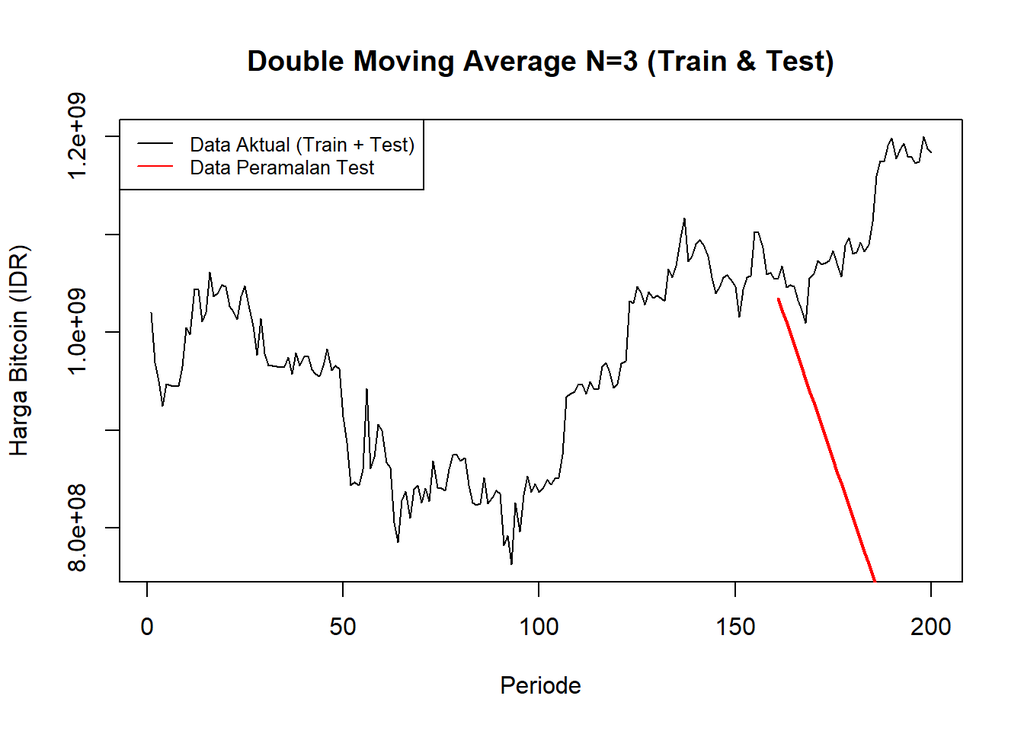

```r
#Visualisasi Plot Data Latih, Data Uji, dan Hasil Ramalan
gabungan_plot <- c(train_data, test_data)
ramalan_lengkap <- c(rep(NA, length(train_data)), ramalan_dma)

ts.plot(gabungan_plot, xlab = "Periode", ylab = "Harga Bitcoin (IDR)",
        main = "Double Moving Average N=3 (Train & Test)",
        ylim = c(min(gabungan_plot, na.rm = TRUE), max(gabungan_plot, na.rm = TRUE)))
lines(ramalan_lengkap, col = "red", lwd = 2)
legend("topleft", c("Data Aktual (Train + Test)", "Data Peramalan Test"),
       lty = 1, col = c("black", "red"), cex = 0.8)
```

# Tahap pelatihan, pengujian, dan visualisasi Single Exponential smoothing(SES)

```r
library(forecast)

#Proses SES menggunakan data latih
dt.ses <- ses(train_data, h = length(test_data))

#Perbandingan data uji dan hasil ramalan
bandingan_ses <- data.frame(
  Data_Uji = test_data,
  Hasil_Ramalan = as.numeric(dt.ses$mean)
)
print(bandingan_ses)
```

```
##      Data_Uji Hasil_Ramalan
## 1  1055520234    1055835399
## 2  1067967578    1055835399
## 3  1046011172    1055835399
## 4  1048833281    1055835399
## 5  1046842891    1055835399
## 6  1033096016    1055835399
## 7  1022574063    1055835399
## 8  1009871406    1055835399
## 9  1055777734    1055835399
## 10 1060456328    1055835399
## 11 1073612578    1055835399
## 12 1069600000    1055835399
## 13 1070884297    1055835399
## 14 1073277031    1055835399
```

[output cut: 26 more lines]

```r
#Menghitung selisish error untuk mengukur tungkat akurasi pada data uji (MAD, MSE, MAPE)
error_ses <- test_data - dt.ses$mean
mad_ses <- mean(abs(error_ses), na.rm = TRUE)
mse_ses <- mean(error_ses^2, na.rm = TRUE)
mape_ses <- mean(abs(error_ses / test_data), na.rm = TRUE) * 100

cat("MAD SES:", mad_ses, "\n")
```

```
## MAD SES: 60758895
```

```r
cat("MSE SES:", mse_ses, "\n")
```

```
## MSE SES: 6.460001e+15
```

```r
cat("MAPE SES:", mape_ses, "% \n")
```

```
## MAPE SES: 5.252814 %
```

```r
print(summary(dt.ses))
```

```
##
## Forecast method: Simple exponential smoothing
##
## Model Information:
## Simple exponential smoothing
##
## Call:
## ses(y = train_data, h = length(test_data))
##
##   Smoothing parameters:
##     alpha = 0.835
##
##   Initial states:
##     l = 973990018.5133
##
##   sigma:  23408590
##
##      AIC     AICc      BIC
## 6245.972 6246.125 6255.197
##
## Error measures:
##                    ME     RMSE      MAE        MPE     MAPE    MASE        ACF1
## Training set 612628.8 23261826 16757631 0.02313765 1.795037 1.00455 0.001626375
##
## Forecasts:
##     Point Forecast      Lo 80      Hi 80      Lo 95      Hi 95
## 161     1055835399 1025836084 1085834714 1009955406 1101715392
## 162     1055835399 1016753374 1094917424  996064600 1115606199
## 163     1055835399 1009415032 1102255766  984841574 1126829224
## 164     1055835399 1003087923 1108582876  975165095 1136505703
## 165     1055835399  997442402 1114228396  966531017 1145139781
## 166     1055835399  992296530 1119374268  958661085 1153009714
## 167     1055835399  987537276 1124133523  951382433 1160288365
## 168     1055835399  983088719 1128582079  944578953 1167091846
## 169     1055835399  978896948 1132773850  938168192 1173502606
## 170     1055835399  974922044 1136748754  932089101 1179581697
## 171     1055835399  971133470 1140537329  926294977 1185375822
## 172     1055835399  967507246 1144163552  920749146 1190921652
## 173     1055835399  964024134 1147646665  915422186 1196248613
## 174     1055835399  960668418 1151002380  910290062 1201380737
```

[output cut: 11 more lines]

```
## 186     1055835399  927048351 1184622448  858872606 1252798193
## 187     1055835399  924634982 1187035817  855181676 1256489123
## 188     1055835399  922265210 1189405588  851557423 1260113375
## 189     1055835399  919936756 1191734042  847996360 1263674438
## 190     1055835399  917647531 1194023268  844495292 1267175506
## 191     1055835399  915395616 1196275183  841051285 1270619513
## 192     1055835399  913179244 1198491554  837661637 1274009161
## 193     1055835399  910996784 1200674014  834323853 1277346945
## 194     1055835399  908846726 1202824073  831035622 1280635176
## 195     1055835399  906727666 1204943132  827794801 1283875998
## 196     1055835399  904638303 1207032495  824599396 1287071403
## 197     1055835399  902577422 1209093376  821447550 1290223249
## 198     1055835399  900543888 1211126910  818337528 1293333270
## 199     1055835399  898536642 1213134157  815267709 1296403089
## 200     1055835399  896554688 1215116110  812236573 1299434226
```

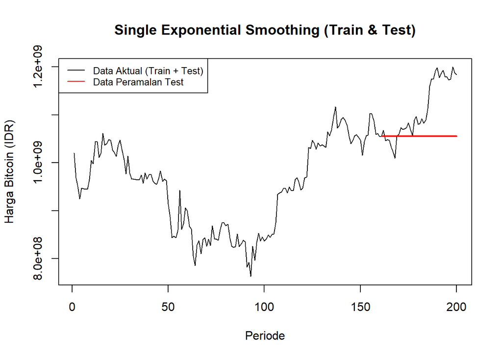

```r
#Plot perbandingan antara(data latih + uji) vs (data hasil peramalan)
gabungan_plot <- c(train_data, test_data)
ramalan_lengkap <- c(rep(NA, length(train_data)), as.numeric(dt.ses$mean))

ts.plot(gabungan_plot, xlab = "Periode", ylab = "Harga Bitcoin (IDR)",
        main = "Single Exponential Smoothing (Train & Test)",
        ylim = c(min(gabungan_plot, na.rm = TRUE), max(gabungan_plot, na.rm = TRUE)))
lines(ramalan_lengkap, col = "red", lwd = 2)
legend("topleft", c("Data Aktual (Train + Test)", "Data Peramalan Test"),
       lty = 1, col = c("black", "red"), cex = 0.8)
```

# Akurasi model menggunakan:

MAD(Mean Absolute Deviation) MSE(Mean Squared Error) MAPE(Mean Absolute Percentage Error) dari masing-masing metode yang sudah dibentuk yaitu(SMA, DMA, dan SES) nilai error terkecil mengindikasi model peramalan terbaik.

```r
dt.akurasi <- data.frame(
  Metode = c("Single Moving Average (SMA)", "Double Moving Average (DMA)", "Single Exponential Smoothing (SES)"),
  MAD = c(mad_sma, mad_dma, mad_ses),
  MSE = c(mse_sma, mse_dma, mse_ses),
  MAPE = c(mape_sma, mape_dma, mape_ses)
)

dt.akurasi
```

```
##                               Metode       MAD          MSE      MAPE
## 1        Single Moving Average (SMA)  59341540 6.197327e+15  5.130869
## 2        Double Moving Average (DMA) 304974058 1.297379e+17 26.671250
## 3 Single Exponential Smoothing (SES)  60758895 6.460001e+15  5.252814
```

# Tahap pelatihan, pengujian, dan visualisasi Double Exponential Smoothing (DES)

DES berfungsi menangani data berpola tren yang menunjukkan arah pergerakan naik atau turun yang konsisten. Nilai peramalan untuk periode ke depan dihitung dengan menggabungkan komponen level terakhir ditambah komponen tren yang dikalikan dengan selang periode waktu peramalan.

```r
library(forecast)

#Metode DES menggunakan data latih
dt.des <- holt(train_data, h = length(test_data))

#Perbandingan antara data uji asli dengan hasil ramalan DES
bandingan_des <- data.frame(
  Data_Uji = test_data,
  Hasil_Ramalan = as.numeric(dt.des$mean)
)
print(bandingan_des)
```

```
##      Data_Uji Hasil_Ramalan
## 1  1055520234    1057799583
## 2  1067967578    1059491349
## 3  1046011172    1061183114
## 4  1048833281    1062874880
## 5  1046842891    1064566646
## 6  1033096016    1066258411
## 7  1022574063    1067950177
## 8  1009871406    1069641943
## 9  1055777734    1071333709
## 10 1060456328    1073025474
## 11 1073612578    1074717240
## 12 1069600000    1076409006
## 13 1070884297    1078100771
## 14 1073277031    1079792537
```

[output cut: 26 more lines]

```r
# Menghitung selisih error untuk mengukur tingkat akurasi pada data uji
error_des <- test_data - dt.des$mean
mad_des <- mean(abs(error_des), na.rm = TRUE)
mse_des <- mean(error_des^2, na.rm = TRUE)
mape_des <- mean(abs(error_des / test_data), na.rm = TRUE) * 100

cat("MAD DES:", mad_des, "\n")
```

```
## MAD DES: 35205480
```

```r
cat("MSE DES:", mse_des, "\n")
```

```
## MSE DES: 2.14278e+15
```

```r
cat("MAPE DES:", mape_des, "% \n")
```

```
## MAPE DES: 3.070575 %
```

```r
print(summary(dt.des))
```

```
##
## Forecast method: Holt's method
##
## Model Information:
## Holt's method
##
## Call:
## holt(y = train_data, h = length(test_data))
##
##   Smoothing parameters:
##     alpha = 0.8422
##     beta  = 0.0072
##
##   Initial states:
##     l = 966386432.4213
##     b = 3543864.0197
##
##   sigma:  23835207
##
##      AIC     AICc      BIC
## 6253.713 6254.102 6269.089
##
## Error measures:
##                    ME     RMSE      MAE        MPE     MAPE     MASE
## Training set -1612669 23535381 17121750 -0.2050837 1.834684 1.026377
##                      ACF1
## Training set -0.004211758
##
## Forecasts:
##     Point Forecast      Lo 80      Hi 80      Lo 95      Hi 95
## 161     1057799583 1027253536 1088345630 1011083435 1104515730
## 162     1059491349 1019412835 1099569862  998196552 1120786145
## 163     1061183114 1013319354 1109046874  987981810 1134384418
## 164     1062874880 1008220383 1117529376  979288041 1146461719
## 165     1064566646 1003780901 1125352391  971602871 1157530420
## 166     1066258411  999817354 1132699468  964645583 1167871239
## 167     1067950177  996216420 1139683934  958242863 1177657492
## 168     1069641943  992902405 1146381480  952278948 1187004937
## 169     1071333709  989821843 1152845574  946672068 1195995349
## 170     1073025474  986935342 1159115606  941361979 1204688969
```

[output cut: 15 more lines]

```
## 186     1100093726  953763052 1246424400  876300272 1323887180
## 187     1101785492  952117902 1251453082  872888666 1330682318
## 188     1103477257  950500336 1256454179  869519245 1337435269
## 189     1105169023  948908294 1261429752  866188861 1344149185
## 190     1106860789  947339899 1266381679  862894641 1350826937
## 191     1108552555  945793434 1271311675  859633960 1357471149
## 192     1110244320  944267326 1276221315  856404412 1364084228
## 193     1111936086  942760129 1281112043  853203787 1370668385
## 194     1113627852  941270511 1285985192  850030046 1377225657
## 195     1115319617  939797243 1290841992  846881310 1383757925
## 196     1117011383  938339186 1295683581  843755838 1390266929
## 197     1118703149  936895285 1300511013  840652016 1396754282
## 198     1120394915  935464561 1305325268  837568346 1403221484
## 199     1122086680  934046102 1310127259  834503432 1409669928
## 200     1123778446  932639056 1314917836  831455975 1416100917
```

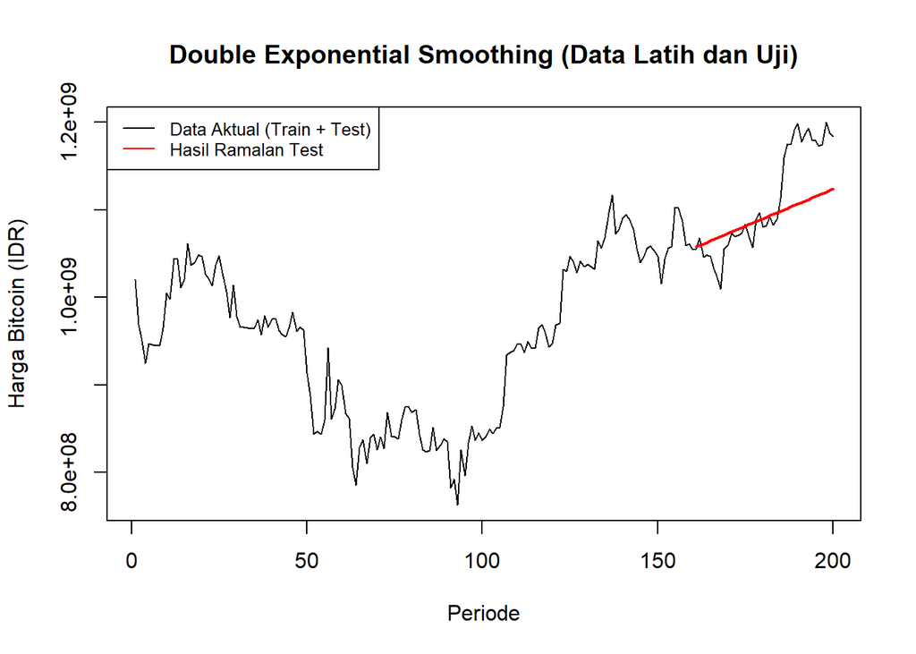

```r
#Plot grafik perbandingan antara (data latih + uji) dengan hasil ramalan DES
gabungan_plot <- c(train_data, test_data)
ramalan_lengkap <- c(rep(NA, length(train_data)), as.numeric(dt.des$mean))

ts.plot(gabungan_plot, xlab = "Periode", ylab = "Harga Bitcoin (IDR)",
        main = "Double Exponential Smoothing (Data Latih dan Uji)",
        ylim = c(min(gabungan_plot, na.rm = TRUE), max(gabungan_plot, na.rm = TRUE)))
lines(ramalan_lengkap, col = "red", lwd = 2)
legend("topleft", c("Data Aktual (Train + Test)", "Hasil Ramalan Test"),
       lty = 1, col = c("black", "red"), cex = 0.8)
```

# Holt-Winters(Winter Adiptif dan Multiplikatif) tidak digunakan karena data pergerakan Bitcoin tidak emiliki pola musiman yang berulang, data Bitcoin merupakan tren harga harian yang fluktuatif tanpa siklus musiman

# Kesimpulan

Metode yang digunakan menggunakan pengujian dan perbandingan model peramalan dengan skema data latih dan dan data uji darii empat metode utama yaitu Single Moving Average(SMAA), Double Moving Average(DMA), Single Exponential Smoothing(SES), dan double Exponential smoothing(DES).

Akurasi model menggunakan: MAD(Mean Absolute Deviation), MSE(Mean Squared Error), dan MAPE(Mean Absolute Percentage Error) dari masing-masing metode yang sudah dibentuk yaitu(SMA, DMA, dan SES) nilai error terkecil mengindikasi model peramalan terbaik.